# FinalExamMarkdownTest

## Final Exam Markdown Test

The IST722 final exam has two parts. The first part, which will be acocmplished in class, will involve using a markdown file to produce diagnostics, graphs, and statistical output for your report. Obviously you will need your laptop to be able to do this. Just before the exam I will provide a template Rmd file to which you will add your own analytical choices. I will also provide your own custom datasets. At the end of that class session, you will submit a “knitted” version of your output to Blackboard. This output will then be the sole basis of your final report.

This file provides a preview of the Rmd file you will receive for the exam. When you click the **Knit** button at the top of the code window an html document will be generated that includes both content as well as the output of any embedded R code chunks within the document. You can embed an R code chunk like this:

```r
summary(mtcars)
```

```
##       mpg             cyl             disp             hp
##  Min.   :10.40   Min.   :4.000   Min.   : 71.1   Min.   : 52.0
##  1st Qu.:15.43   1st Qu.:4.000   1st Qu.:120.8   1st Qu.: 96.5
##  Median :19.20   Median :6.000   Median :196.3   Median :123.0
##  Mean   :20.09   Mean   :6.188   Mean   :230.7   Mean   :146.7
##  3rd Qu.:22.80   3rd Qu.:8.000   3rd Qu.:326.0   3rd Qu.:180.0
##  Max.   :33.90   Max.   :8.000   Max.   :472.0   Max.   :335.0
##       drat             wt             qsec             vs
##  Min.   :2.760   Min.   :1.513   Min.   :14.50   Min.   :0.0000
##  1st Qu.:3.080   1st Qu.:2.581   1st Qu.:16.89   1st Qu.:0.0000
##  Median :3.695   Median :3.325   Median :17.71   Median :0.0000
##  Mean   :3.597   Mean   :3.217   Mean   :17.85   Mean   :0.4375
##  3rd Qu.:3.920   3rd Qu.:3.610   3rd Qu.:18.90   3rd Qu.:1.0000
##  Max.   :4.930   Max.   :5.424   Max.   :22.90   Max.   :1.0000
##        am              gear            carb
##  Min.   :0.0000   Min.   :3.000   Min.   :1.000
##  1st Qu.:0.0000   1st Qu.:3.000   1st Qu.:2.000
##  Median :0.0000   Median :4.000   Median :2.000
##  Mean   :0.4062   Mean   :3.688   Mean   :2.812
##  3rd Qu.:1.0000   3rd Qu.:4.000   3rd Qu.:4.000
##  Max.   :1.0000   Max.   :5.000   Max.   :8.000
```

## Including Plots for your Report

Your report will be enhanced by providing helpful graphs that support the arguments you are trying to make about your data. Code elements in a markdown file can be used to create graphs that will appear in your html output. For example:

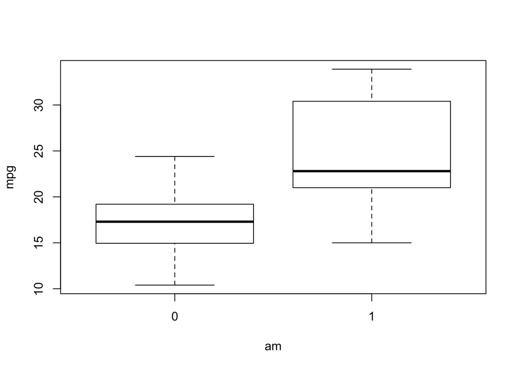

One very important aspect of doing your final exam in this format is that you will have to plan in advance what analyses you will need to conduct. So one of your main tasks during the final class session will be to choose appropriate analyses for your output. For example, the following code produces results for both a t-test and a regression analysis.

```
##
##  Welch Two Sample t-test
##
## data:  mpg by am
## t = -3.7671, df = 18.332, p-value = 0.001374
## alternative hypothesis: true difference in means is not equal to 0
## 95 percent confidence interval:
##  -11.280194  -3.209684
## sample estimates:
## mean in group 0 mean in group 1
##        17.14737        24.39231
```

```
##
## Call:
## lm(formula = mpg ~ hp + wt + gear, data = mtcars)
##
## Residuals:
##     Min      1Q  Median      3Q     Max
## -3.3712 -1.9017 -0.3444  0.9883  6.0655
##
## Coefficients:
##              Estimate Std. Error t value Pr(>|t|)
## (Intercept) 32.013657   4.632264   6.911 1.64e-07 ***
## hp          -0.036786   0.009891  -3.719 0.000888 ***
## wt          -3.197811   0.846546  -3.777 0.000761 ***
## gear         1.019981   0.851408   1.198 0.240963
## ---
## Signif. codes:  0 '***' 0.001 '**' 0.01 '*' 0.05 '.' 0.1 ' ' 1
##
## Residual standard error: 2.574 on 28 degrees of freedom
## Multiple R-squared:  0.8352, Adjusted R-squared:  0.8176
## F-statistic: 47.31 on 3 and 28 DF,  p-value: 4.334e-11
```

Click the **Knit** button to create and inspect your html document. If the knitting process is successful an html file will be submitted to your current working directory. Find that file and submit it to the dropbox on Blackboard to show that you have successfully completed this process.